# Island Urban Climatology: the analysis, step by step

From the logger readings to every number in the thesis: each processing rule, each model, each check, and the package that does it

Justin Kellum, Department of Geography and Environment, University of Hawaiʻi at Mānoa

27 September 2026

# 1 What this document is

The thesis *Island Urban Climatology: Measuring and Modeling Nocturnal Heat in Leeward Coastal Oʻahu, Hawaiʻi* asks which properties of the urban surface explain where night air is warmer or cooler than the rest of a district, using 74 logger sites in Honolulu and ʻEwa on calm, clear nights. Every number, table and figure in it is produced from the files in `data/raw/` by the scripts in `analysis/`, in this order:

| Script | What it does | Runtime |
| --- | --- | --- |
| `00a_compile_logger_readings.R` | reads the loggers’ export tables, separates the download application’s metadata rows from the readings, writes one record of readings and one table of logger metadata, and checks the stored record aga… | seconds |
| `00_prepare_inputs.R` | reads the logger readings, snaps the loggers’ clocks to 30-minute bins, computes the district network median, joins the hourly wind and cloud series, classifies every night, and writes the sensor-nigh… | seconds |
| `01_site_predictors.R` | computes the eight urban-form descriptors of every site at 50, 100 and 200 m from the C-CAP 1 m land-cover masks, the FEMA building footprints (including a ray-cast sky view factor) and the GSHHG shor… | ~7 min |
| `02_models.R` | fits every mixed-effects model of the thesis (scale selection, null models, single descriptors, full and district models, best subsets, interactions, night effect, threshold sensitivity, cross-validat… | ~1 min |
| `03_figures.R` | draws 19 of the 22 main-text figures (all but the two photographs and the terrain figure) with ggplot2 and sf/terra | ~10 min |
| `04_replication_check.R` | compares the R results with the independent Python implementation in `replication/` (Section 9) | seconds |
| `05_thesis_tables.R` | turns the results into 21 of the thesis’s 22 tables (all but the descriptor definitions, which are text), in Markdown, exactly as they appear in the document | seconds |
| `06_elevation_check.R` | the terrain check (thesis Section 4.8): adds the USGS 3DEP elevation of each site to the models, re-runs the best-subset search and the cross-validation with it, and draws Figure 19 | ~1 min |
| `07_sensitivity_checks.R` | three site-level checks (thesis Sections 4.8 and 5.4): the models without the warmest site, with a different height for the buildings whose height the inventory does not record, and with the sky view … | ~7 min |
| `08_appendix_figures.R` | the land-cover and terrain maps and the sky view factor diagram of Appendix B | ~1 min |

`run_all.R` runs them in order (about 30 minutes). This document walks through the chain in the same order, shows the code that does each step, runs the fast parts live, and states which package does what and why it was chosen. It is written so that a reader who knows R but has not seen the project can follow, and rerun, every decision.

```r
source(file.path(root, "analysis", "helpers.R"), encoding = "UTF-8")             # paths, constants, small utilities
source(file.path(root, "analysis", "00_prepare_inputs.R"), encoding = "UTF-8")   # defines load_binned(), night_inventory(), sensor_nights()
suppressPackageStartupMessages({ library(lme4); library(lmerTest); library(performance); library(car); library(sf); library(terra); library(ggplot2); library(kableExtra) })
```

## 1.1 The packages, and what each one does here

| Package | Role | Functions used | Reference |
| --- | --- | --- | --- |
| base R 4.3 | the language; all arithmetic, `median()`, `cor()`, `lm()` for the stepwise check, `wilcox.test()`, `cor.test()` |  | R Core Team (2024) |
| dplyr, tidyr, tibble, purrr | grouped summaries, joins and reshaping of the record (one row per logger and bin → one row per sensor-night) | `group_by()`, `summarise()`, `inner_join()`, `pivot_wider()` | Wickham et al. (2019) |
| readr | fast, typed CSV input and output | `read_csv()`, `write_csv()` | Wickham et al. (2019) |
| lubridate | rounding of the loggers’ time stamps to the nearest 30 minutes | `round_date()`, `ymd_hms()` | Grolemund & Wickham (2011) |
| jsonlite | the results file that the tables and figures read | `write_json()`, `fromJSON()` | Ooms (2014) |
| sf | vector geometry: projecting the sites, buffering, intersecting footprints with circles, ray casting, distance to the shoreline | `st_transform()`, `st_buffer()`, `st_intersects()`, `st_intersection()`, `st_distance()` | Pebesma (2018) |
| terra | raster access: the 1 m C-CAP masks as virtual mosaics, pixel extraction inside circles, aggregation for the base maps | `vrt()`, `extract()`, `crop()`, `aggregate()` | Hijmans (2024) |
| lme4 | the mixed-effects models: random intercept per site, REML and ML fits | `lmer()`, `fixef()`, `ranef()`, `VarCorr()`, `logLik()`, `AIC()`, `predict()` | Bates et al. (2015) |
| lmerTest | Satterthwaite degrees of freedom and t tests for the coefficients | `lmer()` (wrapper), `summary()` | Kuznetsova et al. (2017) |
| performance | marginal and conditional R² (Nakagawa) and ICC, as a check on the manual formulas | `r2_nakagawa()`, `icc()` | Lüdecke et al. (2021) |
| car | variance inflation factors of the predictors | `vif()` | Fox & Weisberg (2019) |
| ggplot2, patchwork, scales, cowplot | all figures; multi-panel layout; colour scales; legend extraction | `ggplot()`, `geom_sf()`, `geom_raster()`, `wrap_plots()` | Wickham (2016); Pedersen (2024) |
| rmarkdown, knitr, kableExtra | this document | `render()`, `kable()` | Xie et al. (2018) |

Why these and not others: `lme4` is the reference implementation of linear mixed models in R; `lmerTest` adds the Satterthwaite approximation that `lme4` deliberately omits, so that each coefficient has a defensible p-value; `sf` and `terra` are the current standard vector and raster packages (the older `sp`/`rgdal`/`raster` stack was retired in 2023); `performance` is used only to confirm that the R² and ICC computed by hand from `VarCorr()` are right. The whole chain is base R plus these packages, with no compiled code of our own and nothing hidden. `results/sessionInfo.txt` records the exact versions of the run that produced the thesis.

# 2 Step 0: from the loggers’ export tables to one record (`00a_compile_logger_readings.R`)

The measurement exists first as the tables produced by the manufacturer’s application when the recovered loggers were read out: one table per district in `data/raw/exports/`, one row per reading (logger, date, time, °C) and one row per logger carrying the application’s metadata as JSON (model, serial number, sample rate, mission start, sample counts). Nothing in these tables has been edited. `00a_compile_logger_readings.R` separates the metadata rows from the readings, writes `data/raw/logger_readings.csv` (every reading, sorted by district, logger and time) and `data/raw/logger_metadata.csv` (one row per logger), and refuses to proceed if a reading is duplicated or if the stored record disagrees with the exports in any reading:

```r
md <- read_csv(file.path(RAW, "logger_metadata.csv"), show_col_types = FALSE)
md %>% count(region, model, sample_rate_s, resolution_c, app_version) %>% tab(caption = "The loggers, as the download application describes them")
```

The loggers, as the download application describes them

| region | model | sample_rate_s | resolution_c | app_version | n |
| --- | --- | --- | --- | --- | --- |
| Ewa | DS1921H | 1800 | 0.5 | 3.5.4 | 38 |
| Honolulu | DS1921H | 1800 | 0.5 | 3.4.14 | 33 |
| Honolulu | DS1921H | 1800 | 0.5 | 3.5.4 | 3 |

```r
md %>% group_by(region) %>% summarise(loggers = n(), readings = sum(readings), first = min(first), last = max(last),
                                     rollover = sum(rollover)) %>% tab()
```

| region | loggers | readings | first | last | rollover |
| --- | --- | --- | --- | --- | --- |
| Ewa | 38 | 77824 | 2024-11-14 20:31:00 | 2024-12-27 14:32:00 | 0 |
| Honolulu | 36 | 73728 | 2024-11-23 21:30:00 | 2025-01-20 08:01:00 | 2 |

Every logger returned exactly 2,048 readings, the capacity of the DS1921H memory (42.7 days at 30 minutes): for 72 loggers the mission simply stopped recording when the memory was full, and for two (HNL01 and HNL34) the memory rolled over, so their record is the last 42.7 days before read-out rather than the first. This is why the Honolulu network thins out after early January (Figure 5 of the thesis), and it is a property of the instrument, not a choice made in processing.

# 3 Step 1: from logger readings to sensor-nights (`00_prepare_inputs.R`)

## 3.1 What comes in

Three files in `data/raw/` and `data/external/`. The logger readings are the record compiled in Step 0: one row per logger and time stamp (no reading has been altered or removed). The sites file gives each logger’s district, position and the setting recorded at deployment. The weather series gives the hourly 10 m wind speed and total cloud cover at the grid point nearest each district (21.34°N 157.80°W for Honolulu, 21.34°N 158.07°W for ʻEwa), retrieved from the Open-Meteo historical-weather API for the whole deployment period by `analysis/inputs/fetch_weather_series.py` (rerunning it reproduces the committed file byte for byte). Open-Meteo’s default historical dataset combines ERA5, ERA5-Land and the ECMWF IFS high-resolution analysis; for this period and place the values are those of the IFS analysis (9 km), which we verified value by value against each model of the API. The thesis calls it the ECMWF analysis.

```r
hh_raw  <- read_csv(file.path(RAW, "logger_readings.csv"), col_types = cols(datetime = col_character(), .default = col_guess()))
sites   <- read_csv(file.path(RAW, "sites.csv"), show_col_types = FALSE)
wx_raw <- read_csv(file.path(EXT, "weather_hourly_series.csv"), col_types = cols(datetime = col_character(), .default = col_guess()))
cat(nrow(hh_raw), "readings from", n_distinct(hh_raw$sensor_id), "loggers;", nrow(sites), "sites;", nrow(wx_raw), "weather rows\n")
```

```
#> 151552 readings from 74 loggers; 74 sites; 10960 weather rows
```

```r
head(hh_raw, 3)
```

| region | sensor_id | datetime | temp_c |
| --- | --- | --- | --- |
| Honolulu | HNL01 | 2024-12-08 16:31:00 | 27.375 |
| Honolulu | HNL01 | 2024-12-08 17:01:00 | 26.125 |
| Honolulu | HNL01 | 2024-12-08 17:31:00 | 25.000 |

```r
sites %>% count(region, setting) %>% tab(caption = "The logger sites by district and recorded setting")
```

The logger sites by district and recorded setting

| region | setting | n |
| --- | --- | --- |
| Ewa | Dense Urban | 22 |
| Ewa | Grass Area with Tree Border | 3 |
| Ewa | High Canopy Park | 1 |
| Ewa | Managed Grassland | 4 |
| Ewa | Multi-use Recreational Park | 2 |
| Ewa | Unmanaged Grassland | 6 |
| Honolulu | Dense Urban | 15 |
| Honolulu | Grass Area with Tree Border | 8 |
| Honolulu | High Canopy Park | 4 |
| Honolulu | Managed Grassland | 3 |
| Honolulu | Managed Wetland | 1 |
| Honolulu | Multi-use Recreational Park | 4 |
| Honolulu | Unmanaged Grassland | 1 |

Every logger reports every 30 minutes, but the loggers were started by hand, so their clocks differ by up to two minutes:

```r
table(minute(read_stamps(hh_raw$datetime)))
```

```
#>
#>     0     1     2    30    31    32
#>  1024 65536  9216  1024 65536  9216
```

This matters for the reference. A median taken over the loggers that share an exact minute stamp would compare the loggers on a :02/:32 cadence (five in Honolulu, four in ʻEwa) with four or five loggers instead of the district network, and one logger (HNL47, alone on :00/:30) with itself. The first processing rule removes the problem.

## 3.2 Rule 1: snap every reading to the nearest 30-minute bin

```r
hh <- hh_raw %>%
  mutate(datetime = read_stamps(datetime),                       # parsed as clock time, no time-zone shift
         time_bin = round_date(datetime, "30 minutes"),          # lubridate: :01 -> :00, :31 -> :30, :02 -> :00 ...
         hour_dec = hour(time_bin) + minute(time_bin) / 60,
         night_date = format(time_bin - hours(NIGHT_END), "%Y-%m-%d"),   # a diurnal date runs 06:00 -> 06:00
         is_night = hour_dec >= NIGHT_START | hour_dec < NIGHT_END)      # 18:00 -> 06:00 HST
```

`round_date()` puts all loggers of a district on the same 30-minute grid; because no stamp ever falls exactly on the quarter-hour, rounding is unambiguous. A diurnal date starts at 06:00 so that a whole night (18:00–06:00) belongs to one date.

## 3.3 Rule 2: the district network median, and ΔT

```r
med <- hh %>% group_by(region, time_bin) %>%
  summarise(network_median_temp = median(temp_c), n_sensors_active = n_distinct(sensor_id), .groups = "drop")
hh <- hh %>% inner_join(med, by = c("region", "time_bin")) %>% mutate(dT_network = temp_c - network_median_temp)
```

## 3.4 Rule 3: attach the weather series

```r
wx <- wx_raw %>% mutate(datetime = read_stamps(datetime), time_bin = round_date(datetime, "30 minutes"),
                          pref = as.integer(minute(datetime) %% 30 != 1)) %>%     # :01/:31 rows first
  arrange(region, time_bin, pref) %>% distinct(region, time_bin, .keep_all = TRUE) %>%
  transmute(region, time_bin, wind_kmh = wind, cloud_pct = cloud)
```

## 3.5 Rules 4 to 6: which nights, which loggers

| Rule | Definition | Constant | Origin |
| --- | --- | --- | --- |
| calm & clear night | ECMWF 10 m wind < 10 km h⁻¹ AND total cloud < 25 % in at least 75 % of the 24 night bins | WIND_MAX_KMH, CLOUD_MAX_PCT, MIN_FRAC_STEPS | study-specific thresholds on the ECMWF analysis; the calm/clear requirement itself follows Oke (1982) and Stewart & Oke (2012) |
| complete weather series | all 24 weather bins of the night present (partial first/last nights are not classified) |  | study-specific |
| network completeness | at least 20 loggers of the district reporting on the night (a median of a handful of loggers is not a district reference) | MIN_SENSORS_PER_NIGHT | study-specific |
| sensor-night completeness | a sensor-night is kept only if at least 18 of its 24 bins are present | MIN_STEPS_PER_SENSOR_NIGHT | study-specific |

```r
b <- load_binned(); hh <- b$hh; wx <- b$wx
inv <- night_inventory(hh, wx)                       # one row per district x diurnal date
sn  <- sensor_nights(hh, inv)                         # one row per logger x selected night
inv %>% count(region, decision) %>% pivot_wider(names_from = region, values_from = n, values_fill = 0) %>% tab()
```

| decision | Ewa | Honolulu |
| --- | --- | --- |
| not calm and clear | 38 | 49 |
| partial night (deployment/retrieval) | 1 | 1 |
| selected | 4 | 7 |
| fewer than 20 sensors reporting | 0 | 1 |

```r
inv %>% filter(selected) %>% select(region, night_date, n_sensors, wind_night, cloud_night, frac_calm_clear) %>%
  mutate(across(where(is.numeric), ~ round(.x, 2))) %>% tab(caption = "The eleven analysed nights")
```

The eleven analysed nights

| region | night_date | n_sensors | wind_night | cloud_night | frac_calm_clear |
| --- | --- | --- | --- | --- | --- |
| Ewa | 2024-11-25 | 38 | 6.12 | 11.54 | 0.75 |
| Ewa | 2024-12-01 | 38 | 1.89 | 16.29 | 0.75 |
| Ewa | 2024-12-21 | 38 | 2.69 | 9.79 | 0.88 |
| Ewa | 2024-12-25 | 38 | 2.61 | 15.42 | 0.75 |
| Honolulu | 2024-11-30 | 35 | 6.92 | 14.75 | 0.75 |
| Honolulu | 2024-12-01 | 35 | 1.71 | 5.21 | 0.92 |
| Honolulu | 2024-12-07 | 35 | 5.99 | 20.25 | 0.79 |
| Honolulu | 2024-12-16 | 36 | 3.20 | 6.96 | 0.92 |
| Honolulu | 2024-12-21 | 36 | 3.38 | 5.29 | 1.00 |
| Honolulu | 2024-12-26 | 36 | 1.61 | 8.00 | 0.92 |
| Honolulu | 2025-01-03 | 36 | 3.28 | 7.46 | 0.96 |

```r
sn %>% group_by(region) %>% summarise(sites = n_distinct(sensor_id), nights = n_distinct(night_date), sensor_nights = n()) %>% tab()
```

| region | sites | nights | sensor_nights |
| --- | --- | --- | --- |
| Ewa | 38 | 4 | 152 |
| Honolulu | 36 | 7 | 248 |

The 400 sensor-nights (36 Honolulu sites × 7 nights minus four incomplete sensor-nights; 38 ʻEwa sites × 4 nights) are the unit of analysis. Their night-mean `dT_night` is what the models explain. The step writes `data/processed/night_inventory.csv`, `sensor_nights.csv` and `halfhourly_calm_clear.csv` (the full diurnal cycles that contain an analysed night, used by the figures and the shared-night comparison).

# 4 Step 2: describing each site (`01_site_predictors.R`)

Eight descriptors are computed for a circle of radius 50, 100 and 200 m around each logger, all from public data and all in the projection of the C-CAP tiles (NAD83(PA11) / UTM 4N, EPSG:6634, metres):

| Descriptor | Source | How | Package |
| --- | --- | --- | --- |
| impervious, tree-canopy and water fractions (%) | NOAA C-CAP 2021, 1 m masks | share of the 1 m pixels whose centre lies inside the circle that carry the class value | terra: `vrt()` builds one virtual mosaic per mask from the tiles; `extract(touches = FALSE)` returns the pixels inside the polygon |
| building footprint fraction (%) | FEMA / ORNL USA Structures | area of footprints clipped to the circle ÷ circle area | sf: `st_intersects()` to find candidates, `st_intersection()` to clip, `st_area()` |
| mean building height (m) | FEMA (height attribute; 5 m where the inventory records none, clipped to 0.5–60 m) | footprint-area-weighted mean of the clipped footprints | sf + base |
| canyon aspect ratio H/W | FEMA | mean height ÷ mean building spacing, spacing = √(circle area / n) − √(mean footprint), W ≥ 6 m, H/W ≤ 5 | base |
| sky view factor (point) | FEMA footprints | 36 rays from the sensor at 1.5 m out to 200 m; along each ray the highest elevation angle β of a footprint; SVF = mean cos²β (Johnson & Watson 1984) | sf: `st_linestring()`, `st_intersection()`, `st_distance()` |
| distance to coast (km) | GSHHG full-resolution shoreline | distance from the sensor to the boundary of the island polygon (Pearl Harbor counts as coast) | sf: `st_union()`, `st_boundary()`, `st_distance()` |

The functions are short enough to read in full. The raster fraction:

```r
raster_fraction <- function(r, geom, values) {
  v <- terra::extract(r, vect(geom), touches = FALSE)[[2]]      # every 1 m pixel whose centre is inside the circle
  n <- length(v)                                                # no-data (0) pixels are read as NA and count towards n
  list(frac = setNames(vapply(values, function(k) 100 * sum(v == k, na.rm = TRUE) / n, numeric(1)), values), n = n)
}
```

The sky view factor, which is the one genuinely three-dimensional descriptor:

```r
sky_view_factor <- function(pt, bldg, z0 = 1.5, R = 200, n_az = 36) {
  cand <- bldg[st_intersects(st_buffer(pt, R), bldg)[[1]], ]                     # footprints within the horizon
  xy <- st_coordinates(pt); total <- 0
  for (k in seq_len(n_az) - 1) {
    th <- 2 * pi * k / n_az
    ray <- st_sfc(st_linestring(rbind(xy, xy + R * c(sin(th), cos(th)))), crs = st_crs(pt))
    hit <- cand[st_intersects(ray, cand)[[1]], ]; beta <- 0
    for (j in seq_len(nrow(hit))) {
      seg <- st_intersection(ray, st_geometry(hit)[j])                          # where the ray enters the footprint
      d <- max(1, as.numeric(st_distance(pt, seg)))                             # horizontal distance to that wall
      beta <- max(beta, atan(max(hit$height_m[j] - z0, 0) / d))                 # elevation angle of the wall top
    }
    total <- total + cos(beta)^2
  }
  total / n_az
}
```

The full computation takes about seven minutes (the building layer holds every footprint on Oʻahu), so this document reads the result rather than recomputing it, and demonstrates the machinery on one site:

```r
source(file.path(root, "analysis", "01_site_predictors.R"), encoding = "UTF-8")       # function definitions only
sites <- read_csv(file.path(PROC, "sensor_nights.csv"), show_col_types = FALSE) %>% distinct(sensor_id, .keep_all = TRUE)   # coordinates come with the stored table
pts <- st_transform(st_as_sf(sites, coords = c("longitude", "latitude"), crs = 4326, remove = FALSE), CRS_M)
p1 <- pts[pts$sensor_id == "HNL50", ]                                          # the compact high-rise site of Waikīkī
circle <- st_buffer(st_geometry(p1), 100, nQuadSegs = 16)
bldg <- buildings_near(st_geometry(p1), 300)                                 # footprints within 300 m, heights filled as in the script
imp <- raster_fraction(ccap_mask("impervious"), circle, LANDCOVER$impervious$value)
bm  <- building_metrics(circle, bldg)
svf <- sky_view_factor(st_geometry(p1), bldg)
cat(sprintf("HNL50 at 100 m: impervious %.1f %% of %d pixels; footprint %.1f %%; mean height %.1f m; H/W %.2f; SVF at the sensor %.2f\n",
            imp$frac[["1"]], imp$n, bm$bldg_frac, bm$zH, bm$hw_ratio, svf))
```

```
#> HNL50 at 100 m: impervious 60.4 % of 31378 pixels; footprint 19.3 %; mean height 6.8 m; H/W 0.39; SVF at the sensor 0.07
```

```r
pred <- read_csv(file.path(DER, "site_predictors_multiscale.csv"), show_col_types = FALSE)
pred %>% filter(sensor_id == "HNL50") %>% select(radius_m, imperv, tree, bldg, height, aspect, svf_point, coast_km) %>%
  mutate(across(-radius_m, ~ round(.x, 2))) %>% tab(caption = "The same site in the stored table (all three radii)")
```

The same site in the stored table (all three radii)

| radius_m | imperv | tree | bldg | height | aspect | svf_point | coast_km |
| --- | --- | --- | --- | --- | --- | --- | --- |
| 50 | 59.50 | 0.68 | 20.31 | 6.05 | 0.39 | 0.07 | 1.7 |
| 100 | 60.35 | 12.20 | 19.32 | 6.79 | 0.39 | 0.07 | 1.7 |
| 200 | 76.17 | 11.46 | 25.54 | 7.83 | 0.47 | 0.07 | 1.7 |

```r
pred %>% filter(radius_m == 100) %>% group_by(region) %>%
  summarise(across(all_of(PRED), ~ round(mean(.x), 2))) %>% tab(caption = "District means of the eight descriptors at 100 m")
```

District means of the eight descriptors at 100 m

| region | imperv | tree | bldg | water | height | svf_point | aspect | coast_km |
| --- | --- | --- | --- | --- | --- | --- | --- | --- |
| Ewa | 52.98 | 9.89 | 12.27 | 0.45 | 4.69 | 0.96 | 0.18 | 2.57 |
| Honolulu | 62.56 | 11.86 | 20.37 | 3.99 | 8.93 | 0.84 | 0.45 | 1.33 |

The step writes `data/descriptors/site_predictors_multiscale.csv`: one row per site and radius.

# 5 Step 3: the mixed-effects models (`02_models.R`)

## 5.1 Why a mixed model, and how it is written in lme4

A site contributes several nights, so its sensor-nights are not independent: whatever makes a site warm on one calm night tends to make it warm on the next. A linear mixed model with a random intercept per site handles this directly. In `lme4` syntax the full pooled model is

```
dT_night ~ region + imperv_z + tree_z + bldg_z + water_z + height_z + svf_point_z + aspect_z + coast_km_z + (1 | sensor_id)
```

where `(1 | sensor_id)` is the site random intercept, `region` is the district (ʻEwa as reference level) and the `_z` predictors are the descriptors standardised with the *pooled* mean and SD, so that one coefficient means “°C per one standard deviation” in every model and is comparable between districts. The wrapper used throughout:

```r
fit_lmm <- function(df, rhs, reml = TRUE) {
  f <- as.formula(paste0("dT_night ~ ", rhs, " + (1 | sensor_id)"))
  lmerTest::lmer(f, data = df, REML = reml,
                 control = lmerControl(optimizer = "bobyqa", optCtrl = list(maxfun = 1e5), check.conv.singular = "ignore"))
}
```

Two conventions run through every step, following Zuur et al. (2009) and Bates et al. (2015):

- **REML for estimates, ML for tests.** Coefficients, standard errors and variance components are reported from REML fits (unbiased variance components). Models that differ in their fixed effects are compared with likelihood-ratio tests and AIC on ML fits, because REML likelihoods of models with different fixed effects are not comparable.
- **Satterthwaite p-values for individual coefficients** (`lmerTest`), which account for the fact that a site-level predictor is effectively tested on 74 sites, not 400 sensor-nights.

## 5.2 The building blocks, run live

```r
source(file.path(root, "analysis", "02_models.R"), encoding = "UTF-8")      # helper functions; main() is not run
d <- load_radius(100)$d
z <- zscore_frame(d, PRED); d <- z$df; sds <- z$sds
```

**Null model and intraclass correlation.** How much of the variance of `dT_night` is between sites rather than between nights within a site?

```r
m0 <- fit_lmm(d, "1", reml = TRUE)
VarCorr(m0)
```

```
#>  Groups    Name        Std.Dev.
#>  sensor_id (Intercept) 0.63500
#>  Residual              0.49059
```

```r
vc <- var_comp(m0); cat(sprintf("ICC = %.3f / (%.3f + %.3f) = %.2f\n", vc$var_site, vc$var_site, vc$var_resid, vc$var_site / (vc$var_site + vc$var_resid)))
```

```
#> ICC = 0.403 / (0.403 + 0.241) = 0.63
```

```r
performance::icc(m0)
```

| ICC_adjusted | ICC_unadjusted | optional |
| --- | --- | --- |
| 0.6262238 | 0.6262238 | FALSE |

**The full pooled model**, as `summary()` prints it:

```r
m_full <- fit_lmm(d, rhs_full("region"), reml = TRUE)
summary(m_full)
```

```
#> Linear mixed model fit by REML. t-tests use Satterthwaite's method [
#> lmerModLmerTest]
#> Formula: f
#>    Data: df
#> Control: ctrl
#>
#> REML criterion at convergence: 728.8
#>
#> Scaled residuals:
#>     Min      1Q  Median      3Q     Max
#> -2.5291 -0.3919 -0.0506  0.3564  6.9153
#>
#> Random effects:
#>  Groups    Name        Variance Std.Dev.
#>  sensor_id (Intercept) 0.2753   0.5247
#>  Residual              0.2402   0.4901
#> Number of obs: 400, groups:  sensor_id, 74
#>
#> Fixed effects:
#>                Estimate Std. Error       df t value Pr(>|t|)
#> (Intercept)     0.23074    0.11951 67.90811   1.931 0.057694 .
#> regionHonolulu -0.33825    0.17731 64.87463  -1.908 0.060864 .
#> imperv_z        0.40336    0.11705 65.74712   3.446 0.000996 ***
#> tree_z         -0.14300    0.07502 65.18761  -1.906 0.061040 .
#> bldg_z         -0.25449    0.13976 65.19763  -1.821 0.073214 .
#> water_z         0.11097    0.08609 62.18391   1.289 0.202164
#> height_z        0.27688    0.10669 63.41885   2.595 0.011731 *
#> svf_point_z    -0.03097    0.07555 62.10405  -0.410 0.683234
#> aspect_z       -0.08128    0.14469 63.19262  -0.562 0.576280
#> coast_km_z     -0.19639    0.07963 66.75451  -2.466 0.016227 *
#> ---
#> Signif. codes:  0 '***' 0.001 '**' 0.01 '*' 0.05 '.' 0.1 ' ' 1
#>
#> Correlation of Fixed Effects:
#>             (Intr) rgnHnl imprv_ tree_z bldg_z watr_z hght_z svf_p_ aspct_
#> regionHonll -0.829
#> imperv_z    -0.009  0.015
#> tree_z       0.070 -0.078  0.248
#> bldg_z       0.030 -0.037 -0.608 -0.084
#> water_z      0.197 -0.210  0.347  0.218 -0.026
#> height_z     0.166 -0.181 -0.130 -0.196  0.223  0.016
#> svf_point_z -0.193  0.207  0.121 -0.017  0.031 -0.011 -0.009
#> aspect_z     0.084 -0.090  0.119  0.220 -0.570  0.024 -0.606  0.012
#> coast_km_z  -0.343  0.369  0.015  0.205  0.151  0.203  0.017  0.112  0.010
```

**Explained variance (Nakagawa & Schielzeth 2013).** R²m is the share of the total variance explained by the fixed effects; R²c adds the site random intercepts:

```r
r2 <- r2_nakagawa(m_full); unlist(r2[c("r2m", "r2c", "icc_cond")])
```

```
#>       r2m       r2c  icc_cond
#> 0.2541226 0.6524692 0.5340645
```

```r
performance::r2_nakagawa(m_full)
```

```
#> # R2 for Mixed Models
#>
#>   Conditional R2: 0.652
#>      Marginal R2: 0.254
```

**Likelihood-ratio test** of the eight predictors given district, on ML fits (this is what `anova()` does for two nested `lmer` fits):

```r
m_full_ml <- fit_lmm(d, rhs_full("region"), reml = FALSE)
m_reg_ml  <- fit_lmm(d, "region", reml = FALSE)
anova(m_reg_ml, m_full_ml, refit = FALSE)
```

|  | npar | AIC | BIC | logLik | deviance | Chisq | Df | Pr(>Chisq) |
| --- | --- | --- | --- | --- | --- | --- | --- | --- |
| m_reg_ml | 4 | 740.7611 | 756.727 | -366.3806 | 732.7611 | NA | NA | NA |
| m_full_ml | 12 | 721.8434 | 769.741 | -348.9217 | 697.8434 | 34.91771 | 8 | 2.767722e-05 |

**Natural units.** A slope per standard deviation is converted back with the pooled SD, e.g. the impervious effect per +10 percentage points:

```r
ct <- coef_table(m_full, sds)
ct %>% filter(term %in% c("imperv_z", "height_z", "coast_km_z")) %>% select(term, estimate, se, df, p, estimate_natural, se_natural, natural_unit) %>%
  mutate(across(where(is.numeric), ~ signif(.x, 3))) %>% tab()
```

| term | estimate | se | df | p | estimate_natural | se_natural | natural_unit |
| --- | --- | --- | --- | --- | --- | --- | --- |
| imperv_z | 0.403 | 0.1170 | 65.7 | 0.000996 | 0.1610 | 0.0466 | per +10 pp |
| height_z | 0.277 | 0.1070 | 63.4 | 0.011700 | 0.0561 | 0.0216 | per +1 m |
| coast_km_z | -0.196 | 0.0796 | 66.8 | 0.016200 | -0.1770 | 0.0718 | per +1 km |

## 5.3 The sequence of analyses in `02_models.R`

The script runs thirteen steps; each writes a CSV table to `results/tables/` and a block of `results/thesis_results.json`. What each one does, and the thesis table, figure and section it feeds:

| Step | What | Method | Thesis |
| --- | --- | --- | --- |
| 1 | descriptives of the predictors by district and radius; district differences | means, SDs; Mann–Whitney (`wilcox.test`) | Table 4, §4.1 |
| 2 | scale selection | full model at 50/100/200 m, pooled and per district, ML AIC; the radius that is best or within 2 AIC in all three (minimax ΔAIC) is adopted; a forward-stepwise OLS on site means (`lm()` + `AIC()`) as … | Table 6, Fig. 13, §4.3 |
| 3 | collinearity | site-level Pearson correlations; VIF from `car::vif()` | Table 7, Fig. 14, §4.4 |
| 4 | null models | intercept-only LMMs, REML; ICC | Table 5, §4.2 |
| 5 | single-predictor models | one predictor at a time, district-adjusted and per district; LRT vs null (ML), R²m | Table 8, Fig. 15, §4.5 |
| 6 | full pooled model and parsimonious model | REML estimates, Satterthwaite p, LRTs; predicted district gap at each district’s mean morphology | Table 9, Fig. 16, §4.6 |
| 7 | district models and best subsets | full 8-predictor model per district; all 93 subsets of ≤ 3 predictors ranked by ML AIC; Akaike weights and predictor importance | Tables 10–12, §4.7 |
| 8 | district × predictor interactions | each interaction added singly to the full model, LRT; joint test of all eight | Table 13, Fig. 17, §4.7 |
| 9 | night effect and night-to-night stability | night as fixed effect, LRT; correlation of site ΔT between nights | Fig. 12, §4.1–4.2 |
| 10 | threshold sensitivity | night selection re-run from the record under 24 rules; models refitted; complement (windy/cloudy) nights | Table 15, Fig. 18, §4.8 |
| 11 | model comparison | ML AIC of OLS, null, district, parsimonious, full and interaction models | Table 14 |
| 12 | site effects, leave-one-site-out CV, calm-core refit | `ranef(condVar = TRUE)`; each site predicted from a model fitted without it (`predict(re.form = NA)`); refit on nights with wind < 5 km h⁻¹ | Table 17, Figs 20 & 21, §4.8–4.9 |
| 13 | shared nights | absolute night-mean medians and percentile bands of both networks on 1 and 21 December | Table 18, Fig. 22, §4.10 |

Three of these deserve a closer look because they are where a reader is most likely to ask “how exactly?”.

### 5.3.1 Best subsets and Akaike weights (step 7)

Every combination of at most three of the eight predictors (93 models including the null) is fitted by ML within each district and ranked by AIC. The Akaike weight of a model is its relative likelihood, `exp(-ΔAIC/2)` normalised over the set; the *importance* of a predictor is the sum of the weights of the models that contain it. This is exactly what `MuMIn::dredge()` would produce; it is written out here so that nothing is hidden:

```r
cands <- c(list(character(0)), unlist(lapply(1:3, function(k) combn(PRED, k, simplify = FALSE)), recursive = FALSE))
rr <- bind_rows(lapply(cands, function(cc) {
  rhs <- if (length(cc)) paste(paste0(cc, "_z"), collapse = " + ") else "1"
  mm <- fit_lmm(g, rhs, reml = FALSE)
  tibble(predictors = if (length(cc)) paste(cc, collapse = " + ") else "(null)", k = length(cc), aic = AIC(mm))
})) %>% mutate(delta_aic = aic - min(aic), weight = exp(-0.5 * delta_aic) / sum(exp(-0.5 * delta_aic))) %>% arrange(aic)
```

```r
res <- fromJSON(file.path(OUT, "thesis_results.json"), simplifyVector = TRUE)
bind_rows(lapply(REGIONS, function(r) as_tibble(res$regional[[r]]$best_subset$top5) %>% mutate(region = r) %>% head(3))) %>%
  select(region, predictors, k, delta_aic, weight, r2m) %>% mutate(across(where(is.numeric), ~ round(.x, 2))) %>%
  tab(caption = "The three best subsets per district")
```

The three best subsets per district

| region | predictors | k | delta_aic | weight | r2m |
| --- | --- | --- | --- | --- | --- |
| Honolulu | imperv + coast_km | 2 | 0.00 | 0.18 | 0.36 |
| Honolulu | imperv + bldg + coast_km | 3 | 0.09 | 0.17 | 0.38 |
| Honolulu | imperv + aspect + coast_km | 3 | 1.61 | 0.08 | 0.36 |
| Ewa | imperv + height + aspect | 3 | 0.00 | 0.66 | 0.31 |
| Ewa | imperv + tree + height | 3 | 3.38 | 0.12 | 0.29 |
| Ewa | imperv + bldg + height | 3 | 5.22 | 0.05 | 0.28 |

### 5.3.2 Threshold sensitivity (step 10)

Because the night-selection thresholds are study-specific choices, the whole selection is re-run from the binned record under a grid of rules (wind 8–20 km h⁻¹, cloud 15–50 %, bin share 60–100 %, and no weather filter at all), and the parsimonious and full pooled models are refitted each time. The only thing that changes between runs is the arguments of `night_inventory()`:

```r
inv <- night_inventory(hh, wx, wind_max = w, cloud_max = cc, min_frac = f)
sn  <- sensor_nights(hh, inv)
```

```r
as_tibble(res$threshold_sensitivity) %>% filter(min_frac == MIN_FRAC_STEPS & cloud_max == CLOUD_MAX_PCT | wind_max %in% c(999, -1)) %>%
  select(wind_max, cloud_max, nights_honolulu, nights_ewa, sensor_nights, beta_imperv_z, beta_height_z, r2m_full, corr_with_baseline) %>%
  mutate(across(where(is.numeric), ~ round(.x, 2))) %>% tab(caption = "Wind threshold varied at cloud < 25 %; 999 = no weather filter, −1 = windy/cloudy nights only")
```

Wind threshold varied at cloud < 25 %; 999 = no weather filter, −1 = windy/cloudy nights only

| wind_max | cloud_max | nights_honolulu | nights_ewa | sensor_nights | beta_imperv_z | beta_height_z | r2m_full | corr_with_baseline |
| --- | --- | --- | --- | --- | --- | --- | --- | --- |
| 8 | 25 | 5 | 4 | 331 | 0.24 | 0.20 | 0.28 | 0.99 |
| 10 | 25 | 7 | 4 | 400 | 0.22 | 0.19 | 0.25 | 1.00 |
| 12 | 25 | 7 | 7 | 514 | 0.21 | 0.19 | 0.24 | 0.99 |
| 15 | 25 | 9 | 11 | 737 | 0.20 | 0.18 | 0.22 | 0.98 |
| 20 | 25 | 11 | 14 | 923 | 0.18 | 0.17 | 0.21 | 0.97 |
| 999 | 999 | 42 | 42 | 3087 | 0.14 | 0.13 | 0.13 | 0.96 |
| -1 | -1 | 35 | 38 | 2687 | 0.13 | 0.12 | 0.12 | 0.95 |

### 5.3.3 Leave-one-site-out cross-validation (step 12)

Each of the 74 sites is held out in turn, the model is refitted on the other sites, and the held-out site’s mean ΔT is predicted from the fixed effects alone (`predict(m, newdata, re.form = NA)`), i.e. from its morphology only. This is the honest measure of how well the descriptors would predict a site that was never measured.

```r
as_tibble(res$loso_cv) %>% select(model, rmse, mae, r, r2_cv) %>% mutate(across(where(is.numeric), ~ round(.x, 2))) %>% tab()
```

| model | rmse | mae | r | r2_cv |
| --- | --- | --- | --- | --- |
| full | 0.63 | 0.49 | 0.39 | 0.09 |
| parsimonious | 0.63 | 0.49 | 0.36 | 0.11 |
| region only | 0.68 | 0.53 | -0.47 | -0.05 |
| Honolulu full | 0.64 | 0.53 | 0.54 | 0.22 |
| Honolulu best subset (imperv + coast_km) | 0.59 | 0.47 | 0.58 | 0.33 |
| Ewa full | 0.47 | 0.39 | 0.65 | 0.41 |
| Ewa best subset (imperv + height + aspect) | 0.44 | 0.36 | 0.71 | 0.49 |

### 5.3.4 Absolute comparison on the shared nights (step 13)

Because ΔT is measured from each district’s own median, the model terms say nothing about which district is warmer. Step 13 answers that on the two calm, clear nights the deployments share (1 and 21 December 2024) from the half-hourly record itself: the network median and the 10th–90th percentile band of each district through the diurnal cycle (thesis Table 18 and Figure 22).

```r
read_csv(file.path(TAB, "shared_nights.csv"), show_col_types = FALSE) %>%
  select(night_date, region, n_sensors, T_median_night, T_p10, T_p90, wind, cloud) %>%
  mutate(across(where(is.numeric), ~ round(.x, 2))) %>% tab(caption = "Night-mean (18:00–06:00) statistics of the two networks on the shared nights")
```

Night-mean (18:00–06:00) statistics of the two networks on the shared nights

| night_date | region | n_sensors | T_median_night | T_p10 | T_p90 | wind | cloud |
| --- | --- | --- | --- | --- | --- | --- | --- |
| 2024-12-01 | Honolulu | 35 | 21.70 | 21.01 | 22.71 | 1.71 | 5.21 |
| 2024-12-01 | Ewa | 38 | 20.05 | 18.88 | 21.08 | 1.89 | 16.29 |
| 2024-12-21 | Honolulu | 36 | 22.01 | 21.15 | 23.22 | 3.38 | 5.29 |
| 2024-12-21 | Ewa | 38 | 20.87 | 19.83 | 21.87 | 2.69 | 9.79 |

# 6 Step 4: the checks (`06_elevation_check.R`, `07_sensitivity_checks.R`)

## 6.1 Terrain (`06_elevation_check.R`)

In Honolulu the strongest single descriptor is distance to the coast, and the shore-to-valley gradient it describes also runs up-slope, so a reader may ask whether the “coast” effect is really an elevation effect. `06_elevation_check.R` answers that with the same machinery: the bare-earth elevation of each logger position (USGS 3DEP 1 m lidar DEM, read through the USGS Elevation Point Query Service and stored with its source raster id in `data/descriptors/site_elevation.csv`) is z-scored like the other descriptors and added to the models. The decisive comparison, run live, is coast alone against coast plus elevation in Honolulu, with `anova()` giving the likelihood-ratio test on ML fits and `summary()` the Satterthwaite t tests of the REML fit:

```r
el <- read_csv(file.path(DER, "site_elevation.csv"), show_col_types = FALSE) %>% select(sensor_id, elev_m)
dh <- d %>% inner_join(el, by = "sensor_id") %>% mutate(elev_m_z = (elev_m - mean(elev_m)) / sd(elev_m)) %>%   # pooled z-score, as for the other descriptors
  filter(region == "Honolulu")
m_coast  <- fit_lmm(dh, "coast_km_z", reml = FALSE)
m_both   <- fit_lmm(dh, "coast_km_z + elev_m_z", reml = FALSE)
m_elev   <- fit_lmm(dh, "elev_m_z", reml = FALSE)
anova(m_coast, m_both, refit = FALSE)          # does elevation add anything given the coast?
```

|  | npar | AIC | BIC | logLik | deviance | Chisq | Df | Pr(>Chisq) |
| --- | --- | --- | --- | --- | --- | --- | --- | --- |
| m_coast | 4 | 294.4125 | 308.4662 | -143.2063 | 286.4125 | NA | NA | NA |
| m_both | 5 | 296.3581 | 313.9253 | -143.1791 | 286.3581 | 0.05437586 | 1 | 0.8156167 |

```r
anova(m_elev,  m_both, refit = FALSE)          # does the coast add anything given elevation?
```

|  | npar | AIC | BIC | logLik | deviance | Chisq | Df | Pr(>Chisq) |
| --- | --- | --- | --- | --- | --- | --- | --- | --- |
| m_elev | 4 | 303.1021 | 317.1558 | -147.5510 | 295.1021 | NA | NA | NA |
| m_both | 5 | 296.3581 | 313.9253 | -143.1791 | 286.3581 | 8.743905 | 1 | 0.003106386 |

```r
summary(fit_lmm(dh, "coast_km_z + elev_m_z", reml = TRUE))$coefficients
```

```
#>                Estimate Std. Error       df    t value    Pr(>|t|)
#> (Intercept) -0.23013646  0.1230278 32.89192 -1.8706050 0.070320075
#> coast_km_z  -0.60883411  0.2023147 32.88911 -3.0093420 0.004995146
#> elev_m_z    -0.03283542  0.1475149 32.75595 -0.2225906 0.825236330
```

Given distance to the coast, elevation adds nothing; given elevation, the coast remains. The script repeats this for the ʻEwa and pooled models, for the best-subset and full models (thesis Table 16), re-runs the exhaustive best-subset search with elevation among the nine candidates, and re-runs the leave-one-site-out cross-validation with and without it:

```r
em <- read_csv(file.path(TAB, "elevation_models.csv"), show_col_types = FALSE)
em %>% filter(scope != "pooled", grepl("elevation|coast only|best subset", model)) %>%
  select(scope, model, r2m, coast_per_km, coast_p, elev_per_10m, elev_p, lrt_elev_given_model_p, delta_aic_vs_without) %>%
  mutate(across(where(is.numeric), ~ round(.x, 3))) %>% tab(caption = "District models with and without site elevation (natural units: °C per km, °C per 10 m)")
```

District models with and without site elevation (natural units: °C per km, °C per 10 m)

| scope | model | r2m | coast_per_km | coast_p | elev_per_10m | elev_p | lrt_elev_given_model_p | delta_aic_vs_without |
| --- | --- | --- | --- | --- | --- | --- | --- | --- |
| Honolulu | elevation only | 0.112 | NA | NA | -0.315 | 0.026 | NA | NA |
| Honolulu | coast only | 0.258 | -0.574 | 0.000 | NA | NA | NA | NA |
| Honolulu | coast + elevation | 0.255 | -0.549 | 0.005 | -0.034 | 0.825 | NA | NA |
| Honolulu | best subset (imperv + coast) | 0.342 | -0.615 | 0.000 | NA | NA | NA | NA |
| Honolulu | best subset (imperv + coast) + elevation | 0.339 | -0.575 | 0.002 | -0.057 | 0.692 | 0.671 | 1.820 |
| Honolulu | full (eight descriptors) + elevation | 0.388 | -0.492 | 0.011 | -0.061 | 0.683 | 0.625 | 1.761 |
| Ewa | elevation only | 0.005 | NA | NA | -0.076 | 0.556 | NA | NA |
| Ewa | coast only | 0.001 | -0.017 | 0.843 | NA | NA | NA | NA |
| Ewa | coast + elevation | 0.005 | 0.022 | 0.841 | -0.096 | 0.560 | NA | NA |
| Ewa | best subset (imperv + height + aspect) | 0.305 | NA | NA | NA | NA | NA | NA |
| Ewa | best subset (imperv + height + aspect) + elevation | 0.307 | NA | NA | -0.070 | 0.442 | 0.406 | 1.309 |
| Ewa | full (eight descriptors) + elevation | 0.330 | -0.013 | 0.867 | -0.093 | 0.394 | 0.316 | 0.996 |

```r
ec <- fromJSON(file.path(OUT, "elevation_check.json"), simplifyVector = FALSE)
cat(sprintf("Best subset with elevation in the pool. Honolulu: %s (elevation importance %.2f); ʻEwa: %s (%.2f)\n",
            ec$subsets$Honolulu$best, ec$subsets$Honolulu$elevation_importance, ec$subsets$Ewa$best, ec$subsets$Ewa$elevation_importance))
```

```
#> Best subset with elevation in the pool. Honolulu: imperv + coast_km (elevation importance 0.11); ʻEwa: imperv + height + aspect (0.02)
```

```r
as_tibble(bind_rows(lapply(ec$loso, as_tibble))) %>% filter(grepl("best subset", model)) %>% mutate(across(where(is.numeric), ~ round(.x, 3))) %>% tab(caption = "Leave-one-site-out skill of the best-subset models with and without elevation")
```

Leave-one-site-out skill of the best-subset models with and without elevation

| scope | model | rmse | mae | r | r2_cv |
| --- | --- | --- | --- | --- | --- |
| Honolulu | best subset (imperv + coast) | 0.592 | 0.474 | 0.578 | 0.326 |
| Honolulu | best subset (imperv + coast) + elevation | 0.599 | 0.481 | 0.566 | 0.309 |
| Ewa | best subset (imperv + height + aspect) | 0.435 | 0.364 | 0.705 | 0.491 |
| Ewa | best subset (imperv + height + aspect) + elevation | 0.451 | 0.372 | 0.682 | 0.454 |

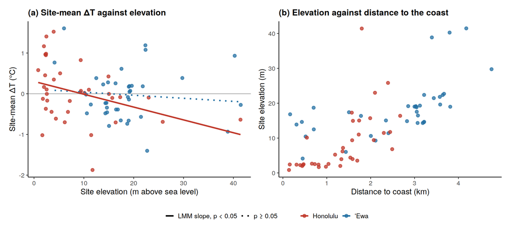

## 6.2 Three site-level checks (`07_sensitivity_checks.R`)

The second check script asks whether any conclusion rests on a single site or on a data-quality detail. It refits the models of `02_models.R` (same z-scores, same random-intercept structure, likelihood-ratio tests on ML fits, REML estimates) under three changes and writes `results/sensitivity_checks.json` and `results/tables/sensitivity_*.csv`:

- **A. HNL08.** The warmest Honolulu site is also among the most variable and is not explained by its descriptors; a generator next to the station was likely the source of its extra warmth (thesis Section 5.4). The models are refitted without its seven sensor-nights, and the check reports how far the Honolulu network median moves when the logger is left out of it.
- **B. Buildings without a recorded height.** About a quarter of the Oʻahu footprints have no height in the USA Structures inventory and carry a 5 m fill value in the footprint file. For each site the share of building area within 100 m that carries the fill value is computed (`data/descriptors/site_default_height_share.csv`); the models are refitted with 3 m instead of 5 m for those buildings (height and canyon aspect ratio recomputed at 100 m) and without the six ʻEwa sites where such buildings make up more than half of the building area.
- **C. Sensor positions inside footprints.** Five recorded positions fall inside a footprint polygon (a post under an eave or a covered walkway, or a position error of a few metres), so the ray casting sees a wall 1 m away in every direction and returns a sky view factor near zero. Their sky view factor is recomputed with the position moved to 1 m outside the nearest footprint edge (`data/descriptors/site_svf_footprint_check.csv`), and the models are refitted.

```r
sc <- fromJSON(file.path(OUT, "sensitivity_checks.json"), simplifyVector = FALSE)
pick <- function(x, what) { cf <- x$pooled_full$coefs; tibble(variant = what, n_sites = x$n_sites, r2m = x$pooled_full$r2m,
  imperv_per_10pp = cf$imperv$est, imperv_p = cf$imperv$p, height_per_m = cf$height$est, height_p = cf$height$p,
  coast_per_km = cf$coast_km$est, coast_p = cf$coast_km$p) }
bind_rows(pick(sc$hnl08$with, "all sites (thesis)"), pick(sc$hnl08$without, "A: without HNL08"),
          pick(sc$default_heights$fill_3m, "B: 3 m for buildings without a recorded height"),
          pick(sc$default_heights$without, "B: without the six sites dominated by them"),
          pick(sc$svf_footprints$corrected, "C: sky view factor recomputed for the five positions")) %>%
  mutate(across(where(is.numeric), ~ signif(.x, 3))) %>% tab(caption = "The full pooled model under each check (natural units)")
```

The full pooled model under each check (natural units)

| variant | n_sites | r2m | imperv_per_10pp | imperv_p | height_per_m | height_p | coast_per_km | coast_p |
| --- | --- | --- | --- | --- | --- | --- | --- | --- |
| all sites (thesis) | 74 | 0.254 | 0.161 | 0.000996 | 0.0561 | 0.0117 | -0.177 | 0.01620 |
| A: without HNL08 | 73 | 0.290 | 0.159 | 0.000500 | 0.0512 | 0.0133 | -0.176 | 0.01020 |
| B: 3 m for buildings without a recorded height | 74 | 0.253 | 0.165 | 0.000756 | 0.0556 | 0.0133 | -0.176 | 0.01730 |
| B: without the six sites dominated by them | 68 | 0.254 | 0.146 | 0.005400 | 0.0556 | 0.0144 | -0.217 | 0.00635 |
| C: sky view factor recomputed for the five positions | 74 | 0.258 | 0.158 | 0.001160 | 0.0550 | 0.0130 | -0.181 | 0.01380 |

```r
as_tibble(bind_rows(lapply(sc$svf_footprints$sites, as_tibble))) %>% mutate(across(where(is.numeric), ~ round(.x, 2))) %>%
  tab(caption = "The five positions inside footprints: sky view factor as recorded and after moving the position 1 m outside the footprint")
```

The five positions inside footprints: sky view factor as recorded and after moving the position 1 m outside the footprint

| sensor_id | region | footprint_height_m | distance_to_edge_m | moved_inside | svf_moved | svf_original |
| --- | --- | --- | --- | --- | --- | --- |
| EWA14 | Ewa | 6.21 | 13.19 | FALSE | 0.61 | 0.04 |
| HNL04 | Honolulu | 4.90 | 1.08 | FALSE | 0.65 | 0.08 |
| HNL21 | Honolulu | 9.94 | 5.02 | FALSE | 0.52 | 0.01 |
| HNL43 | Honolulu | 6.74 | 0.69 | FALSE | 0.54 | 0.04 |
| HNL50 | Honolulu | 5.02 | 0.44 | FALSE | 0.61 | 0.07 |

None of the three changes alters a conclusion: the impervious and building-height effects keep their signs and significance, the district difference in the coastal effect remains, and the ʻEwa height effect is 0.135 rather than 0.131 °C per metre with 3 m fill heights.

# 7 Step 5: figures and tables (`03_figures.R`, `05_thesis_tables.R`, `08_appendix_figures.R`)

Every figure is a ggplot2 object saved as PNG (300 dpi) and PDF in `results/figures/` (the repository keeps the PDF versions of the statistical figures only; the vector maps run to 10 MB each and are regenerated by the script). The maps are built from the same inputs as the descriptors: `terra` crops each C-CAP mask to the district box and aggregates it to 4 m (`aggregate(fact = 4, fun = "mean")`, cached as GeoTIFF), `sf` supplies the island polygon, the building footprints and the site points, and `ggplot2::coord_sf()` draws the graticule. The observed pattern, as an example (thesis Figure 11):

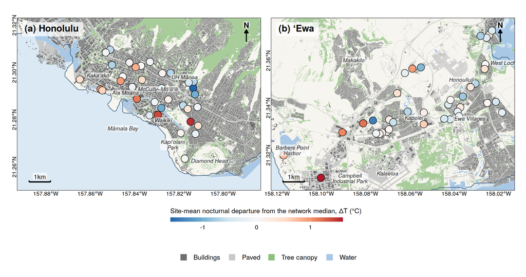

`05_thesis_tables.R` reads `thesis_results.json` and the CSV tables and writes 21 of the thesis’s 22 tables (all but the descriptor definitions) as Markdown files in `results/thesis_tables/`, with the captions and the rounding used in the document, so that every printed number can be traced to a line of code. `08_appendix_figures.R` draws the three figures of Appendix B: the island and district land cover from the aggregated C-CAP masks (with the areas quoted in the thesis’s Section 1.2, `results/island_landcover.json`), the terrain of Oʻahu and Honolulu from the USGS 10 m DEM (the two subsampled grids in `data/external/`), and the sky view factor diagram for one site, drawn with the same ray casting as `01_site_predictors.R` with the angle of every ray kept.

# 8 Reproducing everything

```
Rscript analysis/requirements.R     # installs the packages (once)
Rscript analysis/run_all.R          # ~30 minutes; writes data/processed/, data/descriptors/ and results/
```

`results/sessionInfo.txt` records the exact package versions of the thesis run:

```r
cat(readLines(file.path(OUT, "sessionInfo.txt"))[1:12], sep = "\n")
```

[session information not shown]

The three large inputs (the C-CAP tiles, the FEMA footprints and the GSHHG shoreline) are not in the repository; the README says where to download them and where to put them. Without them, `00_prepare_inputs.R` and every model, table and figure that reads the stored descriptors still run.

# 9 Verification: an independent replication in Python

To guard against an implementation error in any one package, the pipeline up to the results file was written a second time in Python (pandas for the record, rasterio/shapely for the descriptors, statsmodels `MixedLM` for the models; `replication/python/`) and run on the same inputs. `04_replication_check.R` compares the two results files quantity by quantity and writes `replication/replication_check.csv`:

```r
rp <- read_csv(file.path(root, "replication", "replication_check.csv"), show_col_types = FALSE)
cat(sprintf("%d quantities compared; %d differ by more than 0.01\n", sum(!is.na(rp$Python)), sum(abs(rp$difference) > 0.01, na.rm = TRUE)))
```

```
#> 117 quantities compared; 3 differ by more than 0.01
```

```r
rp %>% filter(abs(difference) > 0.01) %>% mutate(across(where(is.numeric), ~ signif(.x, 4))) %>% tab(caption = "The only differences larger than 0.01")
```

The only differences larger than 0.01

| quantity | R | Python | unit | difference |
| --- | --- | --- | --- | --- |
| Scale rule: max ΔAIC at 50 m | 12.34 | 12.32 | NA | 0.02036 |
| Interactions: joint LRT chi2 | 30.43 | 30.42 | NA | 0.01037 |
| Night effect: df (lme4 drops the collinear night dummy) | 9.00 | 10.00 | NA | -1.00000 |

# 10 References for the software

- Bates D, Mächler M, Bolker B, Walker S (2015). Fitting linear mixed-effects models using lme4. *Journal of Statistical Software* 67(1), 1–48. doi:10.18637/jss.v067.i01
- Fox J, Weisberg S (2019). *An R Companion to Applied Regression*, 3rd ed. Sage.
- Grolemund G, Wickham H (2011). Dates and times made easy with lubridate. *Journal of Statistical Software* 40(3), 1–25. doi:10.18637/jss.v040.i03
- Hijmans RJ (2024). terra: Spatial data analysis. R package. https://CRAN.R-project.org/package=terra
- Johnson GT, Watson ID (1984). The determination of view-factors in urban canyons. *Journal of Climate and Applied Meteorology* 23(2), 329–335. doi:10.1175/1520-0450(1984)023<0329:TDOVFI>2.0.CO;2
- Kuznetsova A, Brockhoff PB, Christensen RHB (2017). lmerTest package: tests in linear mixed effects models. *Journal of Statistical Software* 82(13), 1–26. doi:10.18637/jss.v082.i13
- Lüdecke D, Ben-Shachar MS, Patil I, Waggoner P, Makowski D (2021). performance: an R package for assessment, comparison and testing of statistical models. *Journal of Open Source Software* 6(60), 3139. doi:10.21105/joss.03139
- Nakagawa S, Schielzeth H (2013). A general and simple method for obtaining R² from generalized linear mixed-effects models. *Methods in Ecology and Evolution* 4(2), 133–142. doi:10.1111/j.2041-210x.2012.00261.x
- Ooms J (2014). The jsonlite package: a practical and consistent mapping between JSON data and R objects. arXiv:1403.2805
- Pebesma E (2018). Simple features for R: standardized support for spatial vector data. *The R Journal* 10(1), 439–446. doi:10.32614/RJ-2018-009
- Pedersen TL (2024). patchwork: the composer of plots. R package. https://CRAN.R-project.org/package=patchwork
- R Core Team (2024). *R: A language and environment for statistical computing*. R Foundation for Statistical Computing, Vienna. https://www.R-project.org/
- Wickham H (2016). *ggplot2: Elegant Graphics for Data Analysis*. Springer. doi:10.1007/978-3-319-24277-4
- Wickham H, Averick M, Bryan J, et al. (2019). Welcome to the tidyverse. *Journal of Open Source Software* 4(43), 1686. doi:10.21105/joss.01686
- Xie Y, Allaire JJ, Grolemund G (2018). *R Markdown: The Definitive Guide*. Chapman and Hall/CRC.
- Zuur AF, Ieno EN, Walker NJ, Saveliev AA, Smith GM (2009). *Mixed Effects Models and Extensions in Ecology with R*. Springer. doi:10.1007/978-0-387-87458-6